# P4-CP4

## 1. Dada a amostra dos dados do github, podemos eleger o dia mais produtivo de uma linguagem durante a semana?

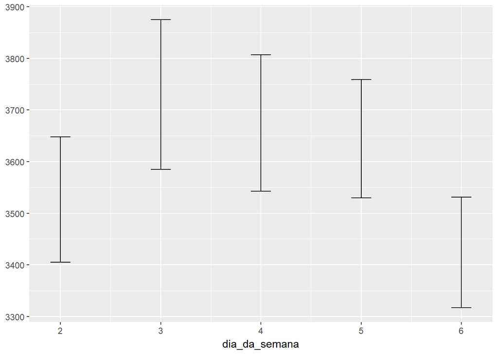

```r
java_repos <- dados_github %>%
  filter(file_extension == 'java') %>%
    mutate(week_day = wday(ymd(paste(the_year, formatC(the_month, width=2, flag="0"), formatC(month_day, width=2, flag="0")))))

java_2 <- java_repos %>%
  filter(week_day == 2)
java_3 <- java_repos %>%
  filter(week_day == 3)
java_4 <- java_repos %>%
  filter(week_day == 4)
java_5 <- java_repos %>%
  filter(week_day == 5)
java_6 <- java_repos %>%
  filter(week_day == 6)

#Fazendo boostrap das medianas para popularidade de cada dia.

java_2_bs = bootstrap(java_2,
                          median(users),
                          R=5000)
java_2_bs.interval = java_2_bs %>%
  CI.percentile(probs = c(.025, .975))
java_3_bs = bootstrap(java_3,
                          median(users),
                          R=5000)
java_3_bs.interval = java_3_bs %>%
  CI.percentile(probs = c(.025, .975))
java_4_bs = bootstrap(java_4,
                          median(users),
                          R=5000)
java_4_bs.interval = java_4_bs %>%
  CI.percentile(probs = c(.025, .975))
java_5_bs = bootstrap(java_5,
                          median(users),
                          R=5000)
java_5_bs.interval = java_5_bs %>%
  CI.percentile(probs = c(.025, .975))
java_6_bs = bootstrap(java_6,
                          median(users),
                          R=5000)
java_6_bs.interval = java_6_bs %>%
  CI.percentile(probs = c(.025, .975))


df = data.frame(rbind(java_2_bs.interval, java_3_bs.interval, java_4_bs.interval, java_5_bs.interval, java_6_bs.interval))
df$dia_da_semana = c(2,3,4,5,6)
df %>%
  ggplot(aes(x = dia_da_semana, ymin = X2.5., ymax = X97.5.)) +
  geom_errorbar(width = .2)
```

Podemos ver que os intervalos de usu?rios est?o bem pr?ximos um dos outros, ter?a feira possui uma mediana entre [3585~3873], com um n?vel de confian?a de 95. Com o mesmo n?vel de confian?a, vemos que a sexta ficou com uma mediana mais baixa: [3317~3531], mas sera que por obter um intervelo abaixo do interlao da mediana da terca feira, pode mos concluir que a terca feira sera um dia mais produtivo que a sexta feira no uso geral (fora da amostra)?

Vamos comparar a diferenca entre terca e quinta, para saber se podemos concluir que um dia tem maior popularidade de java que o outro:

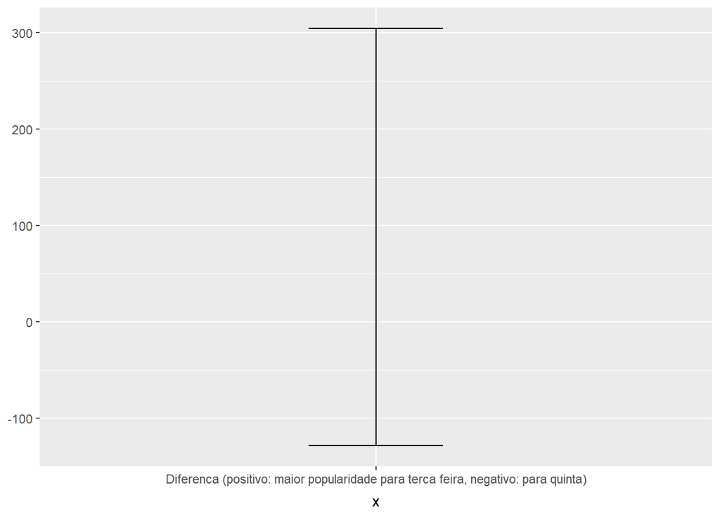

```r
java_diff_35.diff <- bootstrap2(data = (java_3)$users,
               data2 = (java_5)$users,
               median)


java_diff_35.diff.CI = CI.percentile(java_diff_35.diff, probs = c(.025, .975))

data.frame(java_diff_35.diff.CI) %>%
  ggplot(aes(x = "Diferenca (positivo: maior popularidade para terca feira, negativo: para quinta)", ymin = X2.5., ymax = X97.5.)) +
  geom_errorbar(width = .2)
```

No grafico acima, vemos o intervalo que representa a diferenca entre dois dias da semana: terca e quinta feira. Ao analisarmos o intervalo da diferenca, calculado pela mediana, vemos que ele cruzao o zero, indicando que nenhuma conclusao pode ser tirada a partir dele, ou seja, na populacao nao podemos concluir que teremos uma popularidade de java maior na terca do que na quinta, nem ao contrario.

# Teste de Hipotese

Queremos verificar agora se com teste de hipótese podemos conlcuir se existe diferenca entre a popularidade de java para os seguintes dias: terca e quinta. Vamos utilizar os testes de permutacao para implementar nosso teste de hipotese.

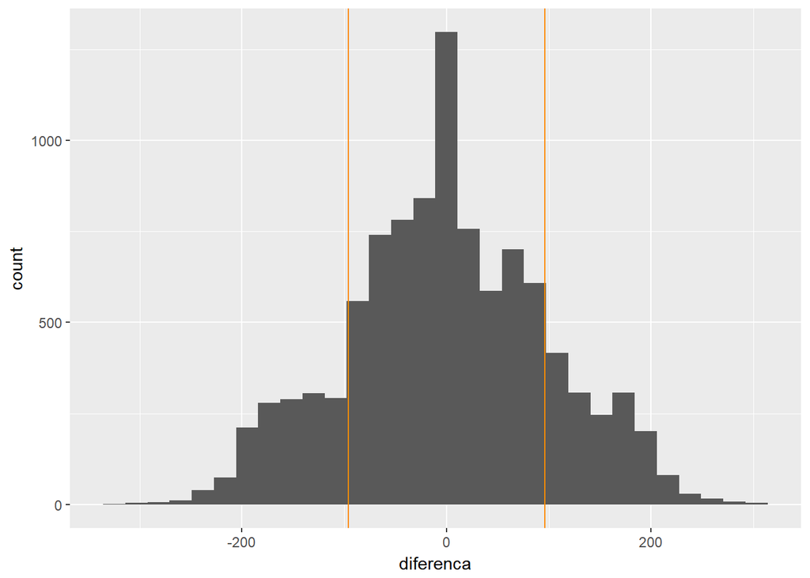

```r
java_35 <- rbind(java_3,java_5)

diffs = replicate(10000, {
  medianas = java_35 %>%
    mutate(dia_embaralhado = sample(week_day, n())) %>%
    group_by(dia_embaralhado) %>%
    summarise(mediana = median(users))
  java_terca = medianas %>%
    filter(dia_embaralhado == "3")
  java_quinta = medianas %>%
    filter(dia_embaralhado == "5")
  return(java_terca$mediana - java_quinta$mediana)
})

diff_median = median(java_3$users) - median(java_5$users)

tibble(diferenca = diffs) %>%
  ggplot(aes(x = diferenca)) +
  geom_histogram(bins = 30) +
  geom_vline(xintercept = diff_median, color='darkorange') +
  geom_vline(xintercept = diff_median * -1, color='darkorange')
```

No grafico acima vemos dois tracos laranjas, esse valor é de +-96, que eh a diferenca das medianas de modificacoes em arquivos java na terca e quinta feira na nossa amostra do github; valores maiores que essa diferenca (em modulo), sao as permutacoes que negam nossa hipotese nula. Hipotese nula: nao existe associacao entre a terca e quinta feira, para a LP Java. Hipotese alternativa: existe associacao entre os dias observados, para a LP Java.

Agora Calculemos o p-valor:

```r
medianas.terca_x_quinta = java_35 %>%
  group_by(week_day) %>%
    summarise(mediana = median(users))

diff.medianas.terca_x_quinta = diff(medianas.terca_x_quinta$mediana)

p.valor = sum(abs(diffs) >= abs(diff.medianas.terca_x_quinta)) / length(diffs)
p.valor
```

```
## [1] 0.3169
```

Temos outras alternativas de calculo do p-valor, que dao valores bem distintos:

```r
wilcox_test(users ~ as.factor(week_day),
            data = java_35,
            distribution = "exact")
```

```
##
##  Exact Wilcoxon-Mann-Whitney Test
##
## data:  users by as.factor(week_day) (3, 5)
## Z = 1.1381, p-value = 0.2564
## alternative hypothesis: true mu is not equal to 0
```

```r
median_test(users ~ as.factor(week_day),
            data = java_35,
            distribution = "exact")
```

```
##
##  Exact Two-Sample Brown-Mood Median Test
##
## data:  users by as.factor(week_day) (3, 5)
## Z = 0.58804, p-value = 0.6147
## alternative hypothesis: true mu is not equal to 0
```

Uma das ferramentas diz ser 25.6%, a outra 61.5%.

# Comparando IC x Teste de hipotese:

Em ambos tivemos resultados condizentes, no primeiro grafico observamos que os resultados sao bem parecidos e que dificilmente chegariamos a uma conclusao assertiva. IC nao nos deu esse resultado assertivo, tampouco o teste de hipotese, que só nos possibilita dizer que nao chegamos a uma conclusao definitiva.